# Great Island 4-6 June

## Receiver Range Testing

On the afternoon of June 4th, I activated a test VHF tag while standing at the receiver station. I then kept that tag with a GPS, which was on and running whenever the tag was in motion (i.e, not in the cabin). On June 5th, we walked a lap of the island’s edge with the GPS and test tag. I then deactivated the tag after walking back to the receiver station on 6 June.

### Simple VHF visualization

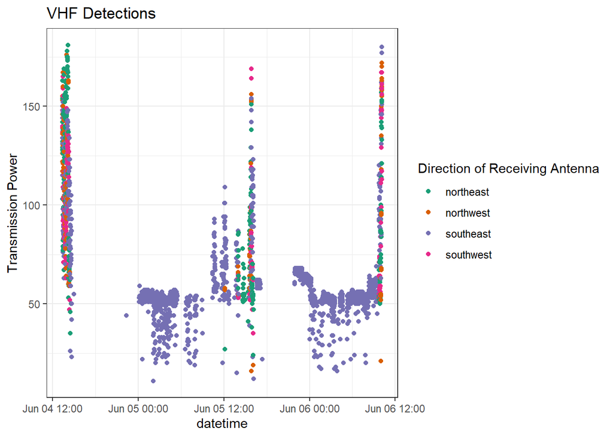

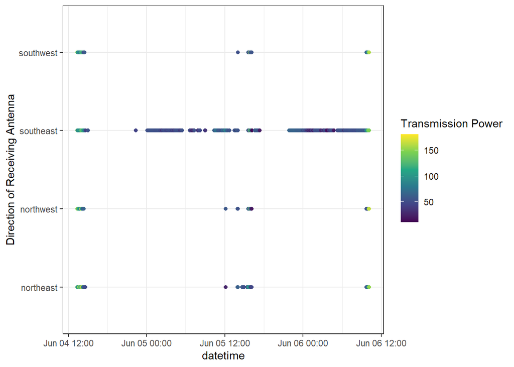

Based on the power level of the detections, we can see three trips near the receiver, interrupted by long stays at the cabin (which is just barely in range of the southeast-facing antenna). If we look at just our lap around the island on June 5th, we can see more detail:

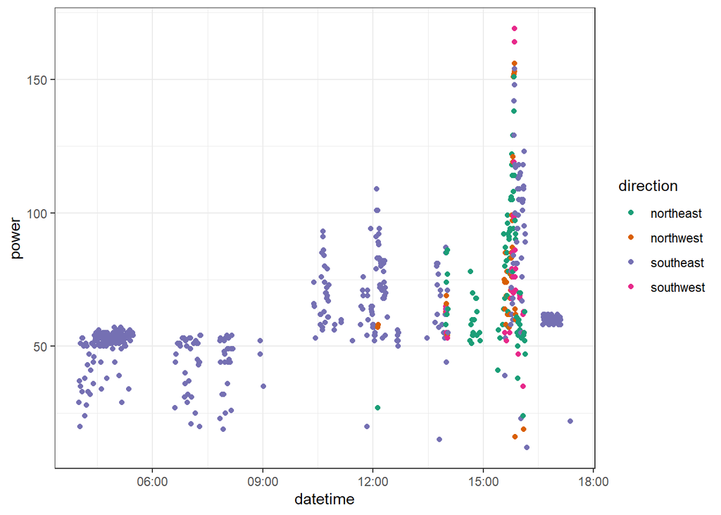

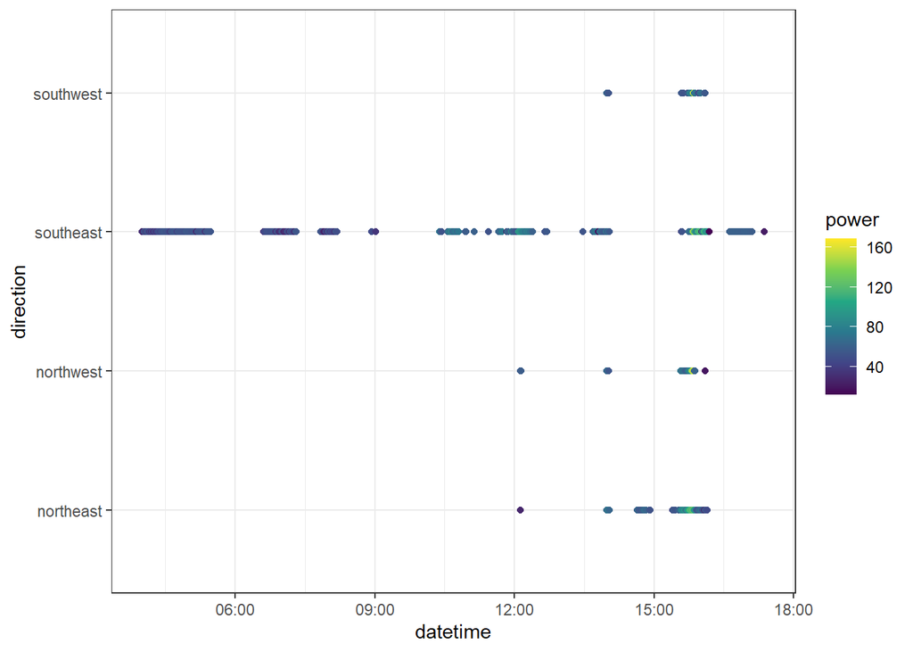

### Combining VHF and GPS points

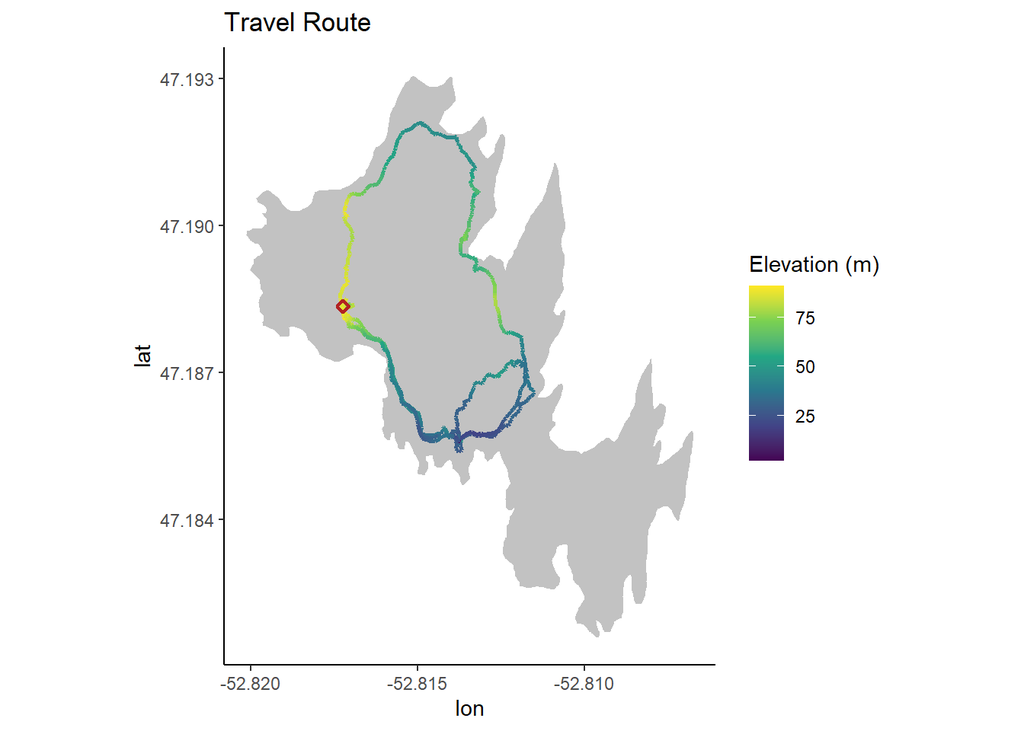

Here is the GPS track from our trip. The receiver station’s location is shown as a red diamond. I went between the cabin and the receiver a few times, made one lap around the northern part of the island, and made one trip to the eastern face that was followed by cutting back through the forest. The next step is to connect these GPS points with the VHF detections.

```r
gps_track <- gps_track %>%
  mutate(bin = round_date(datetime, "1 min"))

bins <- as.list(unique(gps_track$bin))

filtered_vhf <- vhf %>%
  mutate(bin = round_date(datetime, "1 min")) %>%
  filter(bin %in% bins) %>%
  group_by(bin, direction) %>% #preserves one detection from each antenna in each bin
  slice(which.min(datetime))#takes the first detection from each direction in each bin

vhf_positions <- left_join(filtered_vhf, gps_track, by = join_by(closest(datetime > datetime))) %>%
  rename(datetime = datetime.x) %>%
  select(date:direction, lat:ele)

head(vhf_positions)
```

```
# A tibble: 6 × 14
# Groups:   direction [4]
  date       time     channel tag_id antenna power island datetime
  <date>     <time>   <chr>    <dbl>   <dbl> <dbl> <chr>  <dttm>
1 2025-06-04 13:21:22 1          175       4   137 Great  2025-06-04 13:21:22
2 2025-06-04 13:21:30 1          175       4   163 Great  2025-06-04 13:21:30
3 2025-06-04 13:21:37 1          175       1   155 Great  2025-06-04 13:21:37
4 2025-06-04 13:22:08 1          175       3   131 Great  2025-06-04 13:22:08
5 2025-06-04 13:21:54 1          175       2   137 Great  2025-06-04 13:21:54
6 2025-06-04 13:22:31 1          175       4   103 Great  2025-06-04 13:22:31
# ℹ 6 more variables: bearing <dbl>, gain <dbl>, direction <chr>, lat <dbl>,
#   lon <dbl>, ele <dbl>
```

Now we have a dataframe of VHF detections with associated latitudes and longitudes. We can map those referenced detections where the points reflect the location of the tag at the time of transmission, with colors for 1) which antenna received the transmission and 2) the power level of the transmission. Our full GPS track is laid underneath the GPS-referenced detections, so you can see areas where we dipped out of range of the receiver.

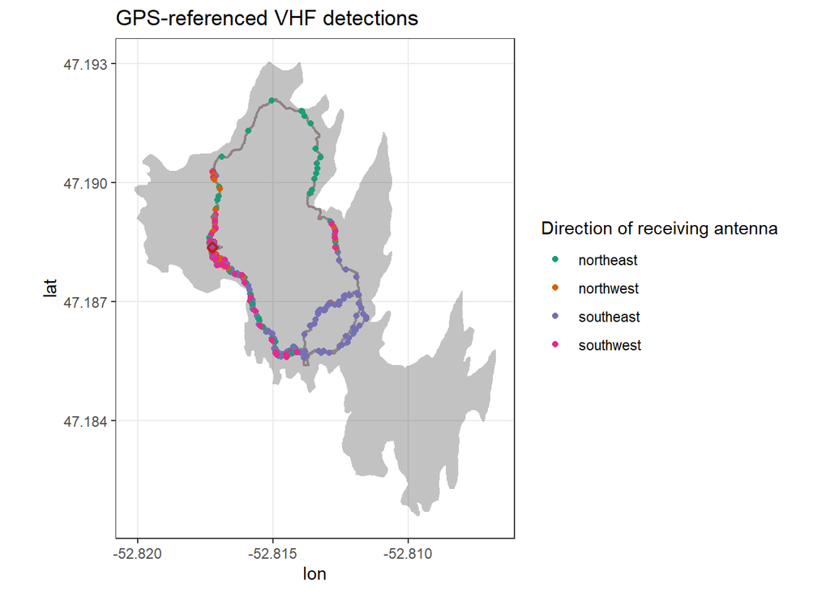

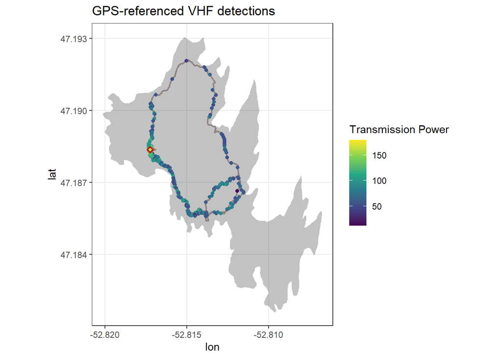

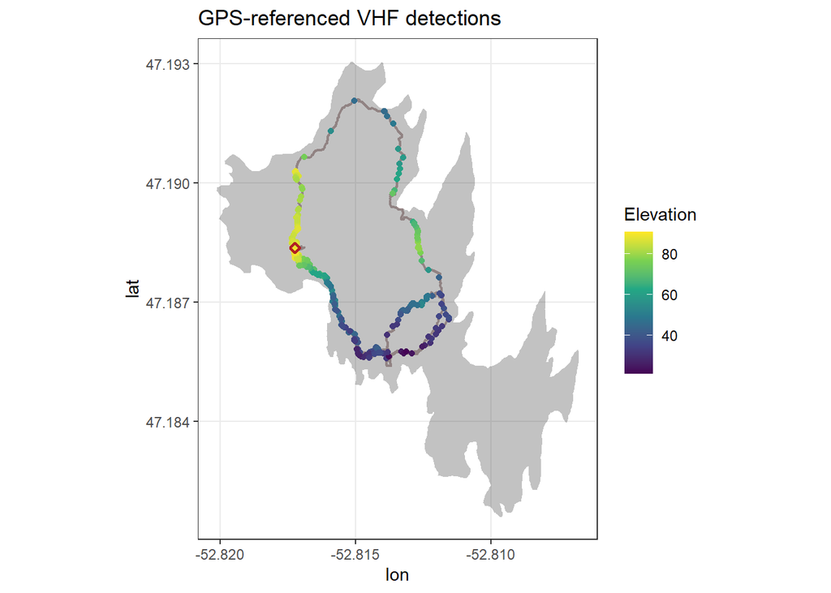

## Mapping Brood Patch Scores

Here is map of all the burrows we grubbed. They were quite clustered together, but the different regions are clear.

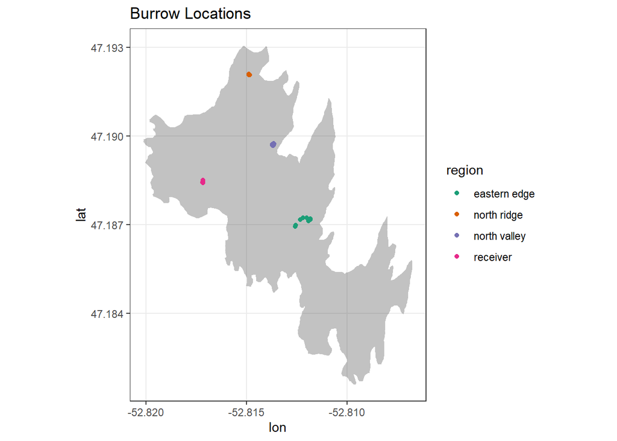

Now the distribution of empty vs. occupied burrows, and of brood patch scores for each bird we found:

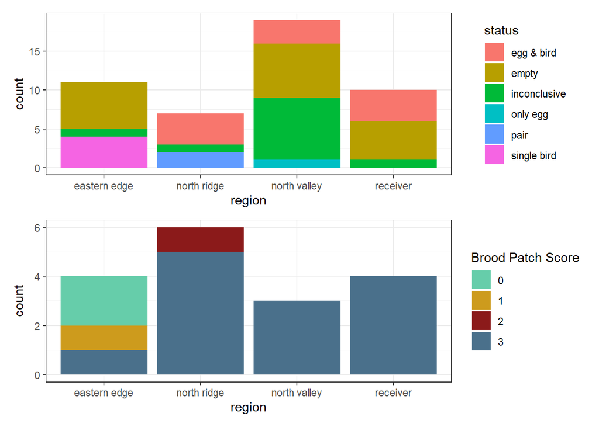